# IGNITE Zagreb workshop: Introduction to Statistics

## Hypothesis testing: a single group

Now let’s say we decide to test 20 people instead of just one. We randomly sample them from the population, apply our treatment, observe that the mean IQ of our sample was 113.3, and we ask the same question:

```r
set.seed(1)
peoplesIQs <- sample(100:130,20, replace = T)
mean(peoplesIQs)
```

```
[1] 113.3
```

> What is the probability of observing a *mean* IQ score as high as we observed given the *null hypothesis* that there was no effect of the treatment?

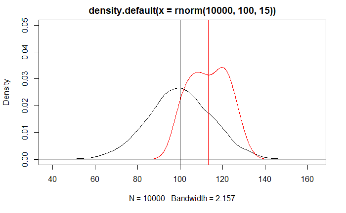

-> We want to compare the mean of the group we have with means of random groups from the population. central limit theorem tells us that the means from the population samples are distributed normally, with mean = mean of the sample and variance = var(sample)/sqrt(N).

Note that the logic of hypothesis testing fundamentally depends on the assumption that our sample is a true random sample from the population. If the mean IQ in the population is 100 but we take a sample of 20 from first year university students, this would represent a biased sample. The IQ scores of first year university students are likely not representative of the population of humans as a whole.

Typically we do not know the mean and standard deviation of the population, we have to estimate them from our sample. The best estimate of the population mean is the sample mean. The best estimate of the population standard deviation is *the standard error of the sampling distribution of the mean*. For very large samples (e.g. N>100) this is fairly accurate. For small samples it is not. Another theoretical sampling distribution exists that is appropriate for these situations: the t-distribution.

## The t-distribution

The t-distribution is similar to the normal distribution, however there is a different shape for each sample size N.

Let’s do the same example as above: We sample 20 subjects at random from the population.

Let’s assume we don’t know the population standard deviation.

$$\begin{equation}
t = \frac{\bar{X}_{1}-\mu}{sd/\sqrt{N}}
\end{equation}$$

```r
(p <- 1-pt(tobs, 19))
```

```
[1] 2.137469e-07
```

#### Confidence Interval for Population Mean

Lets see how good is central limit theorem. Assume we are interested in determining the mean of the bodyweight of the entire untreated mice female population. (untreated are the ones on the “chow” diet = normal diet.)

```r
controlPopulationBodyweight
```

```
  [1] 27.03 24.80 27.02 28.07 23.55 22.72 24.82 21.60 23.98 26.60 19.24 21.43 22.73 20.10 20.60 21.49 24.73 27.92 27.51 19.88
 [21] 20.72 24.00 25.08 25.27 22.08 20.52 23.39 19.87 17.95 31.83 21.71 29.99 20.89 29.60 22.77 26.03 36.84 26.25 22.93 28.25
 [41] 23.84 20.53 24.10 24.79 23.68 21.86 27.25 21.55 24.12 23.07 20.43 24.82 25.43 22.12 20.99 23.28 25.78 22.00 20.74 21.51
 [61] 26.85 25.54 22.51 21.92 21.32 23.59 26.14 20.27 29.60 24.77 22.36 21.65 22.08 26.59 24.60 22.19 29.19 25.14 23.19 27.36
 [81] 23.53 23.54 18.41 28.14 23.34 20.11 18.08 21.03 24.23 19.67 22.66 26.66 20.69 27.42 21.91 16.82 24.47 23.96 23.18 28.80
[101] 26.37 23.61 26.07 27.75 23.70 23.73 24.49 22.87 29.23 21.46 22.12 33.47 24.96 26.15 24.89 19.41 26.36 26.47 23.19 22.32
[121] 20.03 23.51 21.35 21.58 22.27 23.09 23.88 24.04 27.15 18.80 28.07 24.46 25.42 20.28 24.06 15.51 22.51 15.94 19.90 19.44
[141] 22.18 25.97 25.96 23.12 20.98 24.78 22.56 20.36 16.05 17.95 22.71 28.22 21.50 20.30 19.96 19.07 22.35 20.54 30.45 23.54
[161] 20.61 20.18 20.59 23.32 26.35 22.91 25.10 28.46 21.31 28.53 28.43 20.81 27.00 24.55 21.18 21.77 23.80 20.99 23.11 24.82
[181] 22.59 18.47 21.10 25.83 16.31 24.79 26.08 32.74 27.26 31.24 33.81 23.52 27.73 28.26 23.30 18.83 27.70 19.79 27.20 25.40
[201] 26.75 23.45 24.77 23.39 22.95 21.84 28.40 28.21 33.36 29.13 24.21 22.99 24.68 24.67 25.12 23.95 25.69 28.36 24.96 27.36
[221] 26.91 26.58 23.39 20.25 23.22
```

The population average $\mu_X$ is our parameter of interest here:

```r
mu_chow
```

```
[1] 23.89338
```

We are interested in estimating this parameter. In practice, we do not get to see the entire population so, as we did for p-values, we demonstrate how we can use samples to do this. Let’s start with a sample of size 30:

```r
N <- 30
onesample <- sample(PopulationBodyweight,N)
print(mean(onesample))
```

```
[1] 23.798
```

We know this is a random variable, so the sample average will not be a perfect estimate. In fact, because in this illustrative example we know the value of the parameter, we can see that they are not exactly the same. A confidence interval is a statistical way of reporting our finding, the sample average, in a way that explicitly summarizes the variability of our random variable.

So we know its distribution:

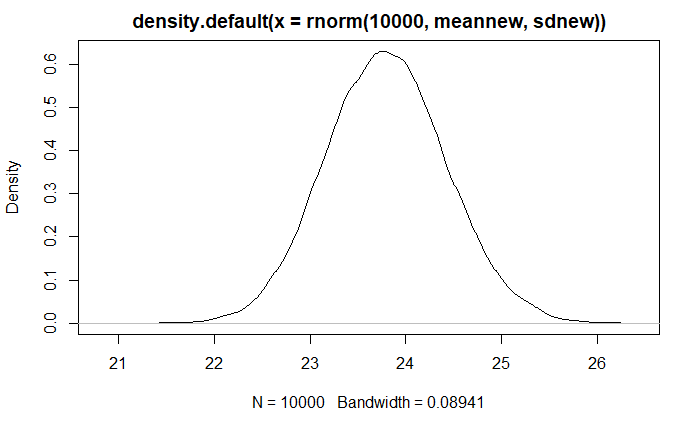

The question now is: what values will this mean have 95% of thew times? This is called a 95% confidence interval.

This is very easy to do in R: since we want 95% confidence interval, we want to leave out bottom 2.5% = 0.025 / 1 and top 2.5 % = 0.975 / 1

```r
c(bottomboundary, topboundary)
```

```
[1] 22.55925 25.03675
```

And there you have it. 95% of the samples of size 30 will have the mean between 22.56 and 25.04.

Confdence interval (we can use percentages other than 95%) is a random interval with a 95% probability of falling on the parameter we are estimating. Keep in mind that saying 95% of random intervals will fall on the true value (our definition above) is *not the same* as saying there is a 95% chance that the true value falls in our interval.

Since the central limit theorem does not work the best with small sample sizes, use the t distribution instead of the normal distribution for small sample sizes. (~ 30).

## Confidence intervals for the mean exercise

Calculate 95% confidence interval for the mean of the population IQs from sample saved in peoplesIQs variable.

```r
# write the interval here
c(qnorm(0.025,newmean, newsd), qnorm(0.975,newmean, newsd))
```

[output not shown]

### In T distribution it would look like this:

The degrees of freedom for the t-statistic are N-1. Note also we divide our $\alpha$ by two in order to get both tails of the t-distribution.

```r
(cim <- c(newmean-(tcrit*newsd), newmean+(tcrit*newsd)))
```

```
[1] 109.4391 114.9609
```

so as you can see it is very similar for large N..

## t-test for difference between groups

Assume we have two random samples, and we want to test the hypotheses that these samples have been drawn from the same population (null hypothesis) or different populations (alternate hypothesis).

There are some important assumptions of the t test. They have to be valid if you plan to trust the results of this test:

- the data you will be testing should follow a continuous or ordinal scale, such as the scores for an IQ test.
- the data is collected from a representative, randomly selected portion of the total population.
- data is normaly distributed when plotted
- resonably large sample size (resembles a bell shaped curve when plotted)
- The final assumption is homogeneity of variance. Homogeneous, or equal, variance exists when the standard deviations of samples are approximately equal.

In R it is dead easy to run a t-test, using the `t.test()` function:

```r
g1 <- c(5,4,4,6,5)
g2 <- c(6,7,5,8,7)
t.test(g1, g2, alternative="two.sided", paired=FALSE, var.equal=TRUE)
```

[output not shown]

Note that we have to tell `t.test()` whether we want a one-tailed or two-tailed test, whether the groups are correlated (paired) or independent, and whether or not we want to assume that group variances are equal or not. The homogeneity of variances is an underlying assumption of the t-test. If it is violated you can simply tell `t.test()` that `var.equal=FALSE` and it will run a corrected version of the test. You can test the homogeneity of variances assumption using `bartlett.test()`:

```r
bartlett.test(c(g1,g2), c(rep(1,5), rep(2,5)))
```

[output not shown]

### Paired t-test

When the two groups are correlated, as in when the same subject contributes a score in each group, we simply pass `t.test()` the argument `paired=TRUE`:

```r
t.test(g1, g2, alternative="two.sided", paired=TRUE, var.equal=TRUE)
```

[output not shown]